# 实验 3: 图像分类器

## 1 实验目的

- 掌握 Pytorch 的使用方法，使用 Pytorch 处理数据，并建立模型。
- 使用 Pytorch 利用 CNN（卷积神经网络）实现一个图像分类器。
- 理解 CNN 用于图像分类的原理

## 2 实验环境

- Kaggle

```python
import os
import sys
import numpy as np
import pandas as pd
import torch

# 查看内存
!free -h

# 查看 Python 版本
print("Python Version:", sys.version)

# 查看已安装库版本
print("NumPy Version:", np.__version__)
print("Pandas Version:", pd.__version__)
print("PyTorch Version:", torch.__version__)
```

```
               total        used        free      shared  buff/cache   available
Mem:            31Gi       1.0Gi        23Gi       1.0Mi       6.9Gi        29Gi
Swap:             0B          0B          0B
Python Version: 3.10.14 | packaged by conda-forge | (main, Mar 20 2024, 12:45:18) [GCC 12.3.0]
NumPy Version: 1.26.4
Pandas Version: 2.2.3
PyTorch Version: 2.4.0
```

## 3 实验数据说明

实验数据为网络上搜集的食物照片，共有11类：Bread, Dairy product, Dessert, Egg, Fried food, Meat, Noodles/Pasta, Rice, Seafood, Soup, and Vegetable/Fruit.

其中，训练集和验证集的图片命名格式为：[类型]_[编号].jpg

```python
import os
dir = '/kaggle/input/dataset/food11'
def count_files_in_folder(folder_path):
    # 直接统计文件夹中的文件数
    return len([f for f in os.listdir(folder_path) if os.path.isfile(os.path.join(folder_path, f))])
train_count = count_files_in_folder(dir+"/training")
valid_count = count_files_in_folder(dir+"/validation")
test_count = count_files_in_folder(dir+"/test")
print(f"size of training data = {train_count}")
print(f"size of valid data = {valid_count}")
print(f"size of test data = {test_count}")
```

```
size of training data = 9866
size of valid data = 3430
size of test data = 3347
```

```
Image size: 512x512
```

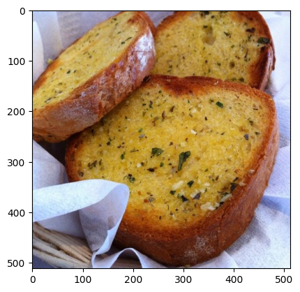

```python
from PIL import Image
import matplotlib.pyplot as plt

# 设置图片文件路径
dir = '/kaggle/input/dataset/food11'
image_path = dir+'/training/0_0.jpg'  # 修改为实际图片路径

# 打开图片
image = Image.open(image_path)

# 获取图片的尺寸 (宽度, 高度)
width, height = image.size

# 输出图片尺寸
print(f"Image size: {width}x{height}")

# 使用 matplotlib 显示图片
plt.imshow(image)
plt.axis('on')  # 开启坐标轴
plt.show()
```

## 4 编写图像分类器

### 4.1 数据预处理

#### 4.1.1 读取数据

```python
import os
import cv2
import numpy as np
import torch
from torch import nn
from torch.utils.data import DataLoader,Dataset
from torch.optim import Adam
import torchvision.transforms as transforms
from torch.autograd import Variable
from PIL import Image
import matplotlib.pyplot as plt
```

```python
def readfile(path,set):
    image_dir = sorted(os.listdir(path))
    x = np.zeros((len(image_dir),128,128,3),dtype = np.uint8) # 初始化，图片长宽为128，RGB三通道
    y = np.zeros((len(image_dir)),dtype = np.uint8) # 存储每张图片类别的向量
    for i ,file in enumerate(image_dir):
        img = cv2.imread(os.path.join(path, file)) # 读取图片
        x[i, :, :, :] = cv2.resize(img, (128,128)) # 将图片进行缩放，压缩为128*128*3
        if set == 'train' or set == 'validation':
            y[i] = int(file.split("_")[0]) # 数据前面是类别，后面是编号

    if set == 'train' or set == 'validation':
        return x, y
    else:
        return x
data_dir = '/kaggle/input/dataset/food11'
train_x ,train_y = readfile(os.path.join(data_dir,"training"),"train")
print(train_x.shape)
val_x ,val_y = readfile(os.path.join(data_dir,"validation"),"validation")
print(val_x.shape)
test_x = readfile(os.path.join(data_dir,"test"),"test")
print(test_x.shape)
```

```
(9866, 128, 128, 3)
(3430, 128, 128, 3)
(3347, 128, 128, 3)
```

#### 4.1.2 重写 ImageDataSet 类进行数据导入

```python
class ImageDataSet(Dataset): #继承Dataset类
    def __init__(self,x,y=None,transform=None):
        self.x = x
        self.y = y
        if y is not None:
            self.y = torch.LongTensor(y) # LongTensor 是用于表示整数类别标签的标准数据类型
        self.transform = transform
    def __len__(self):
        return len(self.x)
    def __getitem__(self,index):
        X = self.x[index] #获取 index 对应的数据
        if self.transform is not None: #如果需要数据增强
            X = self.transform(X)
        if self.y is not None: #如果有类型向量
            Y = self.y[index]
            return X, Y
        else:
            return X
```

#### 4.1.3 使用 Dataloader 读入数据内容

```
Batch of images shape: torch.Size([128, 3, 128, 128])
Labels: tensor([ 5,  1,  6,  9,  9,  3,  4, 10,  6,  3,  0,  6,  1,  1,  0,  3,  3,  0,
         0,  2,  9,  1,  3,  5,  8,  3,  5,  1,  8,  0,  9,  9,  8,  8,  2,  0,
         4,  3,  5,  3,  9,  2,  0,  9,  8,  5,  4,  2,  7,  5,  6,  0,  3,  9,
         5,  3,  3,  6,  2,  2,  7,  3,  0,  1,  6,  5,  9,  5,  3,  2,  0,  2,
         5,  4,  0,  2, 10,  9,  4,  4,  8,  9,  4,  4,  3,  5,  2,  2,  2,  5,
         2, 10, 10,  0,  2, 10,  5,  9,  4, 10,  4,  2,  5,  5,  0,  4,  6,  0,
         2,  9,  2,  2,  4,  4,  9,  2,  9,  2,  0,  2,  0,  9,  5,  2,  9,  4,
         2,  4])
```

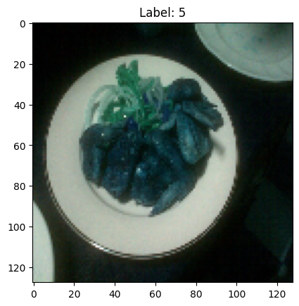

```python
# 使用重写的 ImageDataSet 导入处理好的数据
train_set = ImageDataSet(train_x,train_y,train_transform)
val_set = ImageDataSet(val_x,val_y,test_valid_transform)
test_set = ImageDataSet(test_x,None,test_valid_transform)

#加载数据
batch_size = 128
train_loader = DataLoader(train_set,batch_size=batch_size,shuffle=True)
val_loader = DataLoader(val_set,batch_size=batch_size,shuffle=False)
test_loader = DataLoader(test_set,batch_size=batch_size,shuffle=False)

# 获取一个batch的数据
data_iter = iter(train_loader)
images, labels = next(data_iter)

# 输出图像的形状
print(f"Batch of images shape: {images.shape}")
print(f"Labels: {labels}")  # 输出标签

# 显示第一张图片
plt.imshow(images[0].permute(1, 2, 0).cpu())  # permute: 转换维度为 HxWxC
plt.title(f"Label: {labels[0].item()}")
plt.show()
```